# Исследование технологического процесса очистки золота

# Содержание

**Цели исследования:**

По данным с параметрами добычи и очистки руд подготовить прототип модели машинного обучения для компании «Цифры», которая разрабатывает решения для работы промышленных предприятий. Модель должна предсказать коэффициент восстановления золота из золотосодержащей руды. Модель поможет оптимизировать производство, чтобы не запускать предприятие с убыточными характеристиками.

**Ход исследования:**

- Подготовка данных
  - Изучение данных
  - Проверка правильности рассчета эффективности обогащения
  - Анализ признаков
  - Предобработка данных
- Исследовательский анализ данных
  - Динамика изменения концентрации металлов в зависимости от этапа очистки
  - Сравнение размеров гранул сырья на разных выборках
  - Исследование суммарной концентрации всех веществ на разных стадиях
- Построение и обучени модели
  - Формулирование и оформление метрики sMAPE
  - Обучение различных моделей с оценкой их качества кросс-валидацией, выбор лучшей
  - Выводы

**Итоги исследования:**

В ходе работы были проанализированы и обработаны предоставленные данные и подготовлена модель машинного обучения, способная на обучающей выборке выдавать прогнозный коэффициент восстановления золота лучше baseline (Dummy Regressor). В итоге, удалось обучить модель машинного обучения, которая по метрике sMAPE лучше альтернатив, включая константную baseline модель.

## Описание данных

### Технологический процесс

```
Rougher feed — исходное сырье
Rougher additions (или reagent additions) — флотационные реагенты: Xanthate, Sulphate, Depressant

Xanthate **— ксантогенат (промотер, или активатор флотации);
Sulphate — сульфат (на данном производстве сульфид натрия);
Depressant — депрессант (силикат натрия).

Rougher process (англ. «грубый процесс») — флотация
Rougher tails — отвальные хвосты
Float banks — флотационная установка
Cleaner process — очистка
Rougher Au — черновой концентрат золота
Final Au — финальный концентрат золота
```

### Параметры этапов

```
air amount — объём воздуха
fluid levels — уровень жидкости
feed size — размер гранул сырья
feed rate — скорость подачи
```

### Наименование признаков

Наименование признаков должно быть такое: [этап].[тип_параметра].[название_параметра] Пример: rougher.input.feed_ag

Возможные значения для блока [этап]:

```
rougher — флотация
primary_cleaner — первичная очистка
secondary_cleaner — вторичная очистка
final — финальные характеристики
```

Возможные значения для блока [тип_параметра]:

```
input — параметры сырья
output — параметры продукта
state — параметры, характеризующие текущее состояние этапа
calculation — расчётные характеристики
```

```python
import pandas as pd
import numpy as np
import matplotlib.pyplot as plt
import seaborn as sns

from sklearn.model_selection import cross_val_score, GridSearchCV, RandomizedSearchCV
from sklearn.metrics import mean_absolute_error, make_scorer
from sklearn.preprocessing import StandardScaler

from sklearn.dummy import DummyRegressor
from sklearn.tree import DecisionTreeRegressor
from sklearn.ensemble import RandomForestRegressor
from sklearn.linear_model import LinearRegression
```

## Знакомство с данными и их подготовка

### Открытие файлов и их изучение

```python
data_train = pd.read_csv('/home/panther/Documents/Deep Learning/datasets/gold_recovery_train_new.csv', index_col='date')
data_test = pd.read_csv('/home/panther/Documents/Deep Learning/datasets/gold_recovery_test_new.csv', index_col='date')
data_full = pd.read_csv('/home/panther/Documents/Deep Learning/datasets/gold_recovery_full_new.csv', index_col='date')
```

```python
# глобальные опции и переменные

random_state = 42
np.random.seed(random_state)
pd.set_option('display.max_columns', None)
pd.set_option('display.max_rows', 100)


metals = ['au', 'ag', 'pb']
elements = metals + ['sol']
target_features = ['rougher.output.recovery', 'final.output.recovery']
feed_features = ['rougher.input.feed', 'rougher.output.concentrate',
                 'primary_cleaner.output.concentrate', 'final.output.concentrate']
```

```python
data_full.describe()
```

|  | final.output.concentrate_ag | final.output.concentrate_pb | final.output.concentrate_sol | final.output.concentrate_au | final.output.recovery | final.output.tail_ag | final.output.tail_pb | final.output.tail_sol | final.output.tail_au | primary_cleaner.input.sulfate | primary_cleaner.input.depressant | primary_cleaner.input.feed_size | primary_cleaner.input.xanthate | primary_cleaner.output.concentrate_ag | primary_cleaner.output.concentrate_pb | primary_cleaner.output.concentrate_sol | primary_cleaner.output.concentrate_au | primary_cleaner.output.tail_ag | primary_cleaner.output.tail_pb | primary_cleaner.output.tail_sol | primary_cleaner.output.tail_au | primary_cleaner.state.floatbank8_a_air | primary_cleaner.state.floatbank8_a_level | primary_cleaner.state.floatbank8_b_air | primary_cleaner.state.floatbank8_b_level | primary_cleaner.state.floatbank8_c_air | primary_cleaner.state.floatbank8_c_level | primary_cleaner.state.floatbank8_d_air | primary_cleaner.state.floatbank8_d_level | … |
| --- | --- | --- | --- | --- | --- | --- | --- | --- | --- | --- | --- | --- | --- | --- | --- | --- | --- | --- | --- | --- | --- | --- | --- | --- | --- | --- | --- | --- | --- | --- |
| count | 19438.000000 | 19438.000000 | 19228.000000 | 19439.000000 | 19439.000000 | 19438.000000 | 19338.000000 | 19433.000000 | 19439.000000 | 19415.000000 | 19402.000000 | 19439.000000 | 19335.000000 | 19439.000000 | 19323.000000 | 19069.000000 | 19439.000000 | 19435.000000 | 19418.000000 | 19377.000000 | 19439.000000 | 1.943500e+04 | 19438.000000 | 1.943500e+04 | 19438.000000 | 1.943700e+04 | 19438.000000 | 1.943600e+04 | 19438.000000 | … |
| mean | 5.168470 | 9.978895 | 9.501224 | 44.076513 | 67.050208 | 9.688589 | 2.705795 | 10.583728 | 3.042467 | 144.624774 | 8.817039 | 7.307078 | 1.021795 | 8.442408 | 9.829530 | 10.489499 | 32.119400 | 16.145826 | 3.435656 | 7.973209 | 3.914179 | 1.589354e+03 | -491.195012 | 1.591344e+03 | -492.192978 | 1.586669e+03 | -491.980070 | 1.542912e+03 | -488.017382 | … |
| std | 1.372348 | 1.669240 | 2.787537 | 5.129784 | 10.125840 | 2.328642 | 0.949077 | 2.868782 | 0.922808 | 44.464071 | 3.286186 | 0.613509 | 0.513254 | 2.054465 | 2.556843 | 3.909639 | 5.627611 | 3.548598 | 1.392536 | 2.212677 | 1.593034 | 1.289968e+02 | 32.431842 | 1.318109e+02 | 33.794822 | 1.361114e+02 | 32.711455 | 2.461996e+02 | 43.959780 | … |
| min | 0.000000 | 0.000000 | 0.000000 | 0.000000 | 0.000000 | 0.000000 | 0.000000 | 0.000000 | 0.000000 | 0.003112 | 0.000000 | 1.080000 | 0.000005 | 0.000000 | 0.000000 | 0.000000 | 0.000000 | 0.000000 | 0.000000 | 0.000000 | 0.000000 | 5.445860e-32 | -798.641662 | 6.647490e-32 | -799.997015 | 4.033736e-32 | -799.960571 | 4.039220e-32 | -799.794250 | … |
| 25% | 4.251240 | 9.137262 | 7.722820 | 43.402215 | 63.299712 | 8.062878 | 2.040119 | 8.938947 | 2.461138 | 114.107029 | 6.076909 | 6.940000 | 0.697224 | 7.263288 | 8.702328 | 7.893893 | 30.463140 | 14.017742 | 2.504365 | 6.747483 | 2.924844 | 1.505063e+03 | -500.308544 | 1.503630e+03 | -500.437171 | 1.500927e+03 | -500.703932 | 1.494219e+03 | -500.458365 | … |
| 50% | 5.066094 | 10.102433 | 9.218961 | 45.011244 | 68.172738 | 9.743623 | 2.748730 | 10.622456 | 2.984909 | 143.232103 | 8.038311 | 7.280000 | 0.940863 | 8.507298 | 10.152433 | 10.314632 | 32.841295 | 15.842836 | 3.271153 | 8.183673 | 3.623234 | 1.600597e+03 | -499.926134 | 1.600521e+03 | -499.956767 | 1.600254e+03 | -499.909524 | 1.599447e+03 | -499.905974 | … |
| 75% | 5.895527 | 11.035769 | 10.947813 | 46.275313 | 72.686642 | 11.134294 | 3.333216 | 12.104271 | 3.571351 | 175.075656 | 11.013521 | 7.670000 | 1.210990 | 9.809001 | 11.424971 | 13.446702 | 35.048006 | 18.013975 | 4.181748 | 9.548586 | 4.585705 | 1.697658e+03 | -499.433950 | 1.699218e+03 | -499.373336 | 1.699483e+03 | -498.857643 | 1.698525e+03 | -499.064695 | … |
| max | 16.001945 | 17.031899 | 19.615720 | 52.756638 | 100.000000 | 19.552149 | 5.804178 | 22.317730 | 8.245022 | 265.983123 | 40.000000 | 15.500000 | 4.102454 | 16.081632 | 17.081278 | 22.458114 | 45.933934 | 29.459575 | 9.634565 | 22.276364 | 17.788925 | 2.103104e+03 | -57.195404 | 2.114907e+03 | -142.527229 | 2.013156e+03 | -150.937035 | 2.398904e+03 | -30.601828 | … |

```python
data_full.info()
```

```
<class 'pandas.core.frame.DataFrame'>
Index: 19439 entries, 2016-01-15 00:00:00 to 2018-08-18 10:59:59
Data columns (total 86 columns):
 #   Column                                              Non-Null Count  Dtype
---  ------                                              --------------  -----
 0   final.output.concentrate_ag                         19438 non-null  float64
 1   final.output.concentrate_pb                         19438 non-null  float64
 2   final.output.concentrate_sol                        19228 non-null  float64
 3   final.output.concentrate_au                         19439 non-null  float64
 4   final.output.recovery                               19439 non-null  float64
 5   final.output.tail_ag                                19438 non-null  float64
 6   final.output.tail_pb                                19338 non-null  float64
 7   final.output.tail_sol                               19433 non-null  float64
 8   final.output.tail_au                                19439 non-null  float64
 9   primary_cleaner.input.sulfate                       19415 non-null  float64
```

[output cut: 78 more lines]

Все данные (кроме индекса) в типе чисел с плавающей точкой, в некоторых колонках имеются пропуски.

Проверка на дубликаты:

```python
print('Явных дубликатов строк найдено:')
print(f'train: {data_train.duplicated().sum()}')
print(f'test: {data_test.duplicated().sum()}')
print(f'full: {data_full.duplicated().sum()}')
```

```
Явных дубликатов строк найдено:
train: 0
test: 0
full: 0
```

Различия в выборках:

```python
print(f'Признаки в train и full одинаковы: {set(data_train.columns) == set(data_full.columns)}')
```

```
Признаки в train и full одинаковы: True
```

```python
print(f'Признаки в train и test одинаковы: {set(data_train.columns) == set(data_test.columns)}')
print()
print('Отличаются следующие признаки:')
set(data_train.columns).union(set(data_test.columns)) - set(data_train.columns).intersection(set(data_test.columns))
```

```
Признаки в train и test одинаковы: False

Отличаются следующие признаки:
```

```
{'final.output.concentrate_ag',
 'final.output.concentrate_au',
 'final.output.concentrate_pb',
 'final.output.concentrate_sol',
 'final.output.recovery',
 'final.output.tail_ag',
 'final.output.tail_au',
 'final.output.tail_pb',
 'final.output.tail_sol',
 'primary_cleaner.output.concentrate_ag',
 'primary_cleaner.output.concentrate_au',
 'primary_cleaner.output.concentrate_pb',
 'primary_cleaner.output.concentrate_sol',
 'primary_cleaner.output.tail_ag',
 'primary_cleaner.output.tail_au',
 'primary_cleaner.output.tail_pb',
 'primary_cleaner.output.tail_sol',
 'rougher.calculation.au_pb_ratio',
 'rougher.calculation.floatbank10_sulfate_to_au_feed',
 'rougher.calculation.floatbank11_sulfate_to_au_feed',
 'rougher.calculation.sulfate_to_au_concentrate',
 'rougher.output.concentrate_ag',
 'rougher.output.concentrate_au',
 'rougher.output.concentrate_pb',
 'rougher.output.concentrate_sol',
 'rougher.output.recovery',
 'rougher.output.tail_ag',
 'rougher.output.tail_au',
 'rougher.output.tail_pb',
 'rougher.output.tail_sol',
 'secondary_cleaner.output.tail_ag',
 'secondary_cleaner.output.tail_au',
 'secondary_cleaner.output.tail_pb',
 'secondary_cleaner.output.tail_sol'}
```

Имеются различия в наборах признаков для тестовой выборки в сравнении с полной и тренировочной выборками. Придется корректировать позже.

### Проверка корректности расчета recovery

Recovery считается так: $$R = {C(F-T) \over F(C-T)} \cdot 100\%$$

где:

```
C ('rougher.output.concentrate_au') — доля золота в концентрате после флотации/очистки;
F ('rougher.input.feed_au') — доля золота в сырье/концентрате до флотации/очистки;
T ('rougher.output.tail_au') — доля золота в отвальных хвостах после флотации/очистки.
```

```python
def recovery(data):
    C = data['rougher.output.concentrate_au']
    F = data['rougher.input.feed_au']
    T = data['rougher.output.tail_au']
    return (C * (F - T)) / (F * (C - T)) * 100
```

Проверка корректности эффективности обогащения золота:

```python
calculated_recovery = recovery(data_train)
existing_recovery = data_train['rougher.output.recovery']
pd.concat([calculated_recovery.head(), existing_recovery.head()], axis=1)
```

| date | 0 | rougher.output.recovery |
| --- | --- | --- |
| 2016-01-15 00:00:00 | 87.107763 | 87.107763 |
| 2016-01-15 01:00:00 | 86.843261 | 86.843261 |
| 2016-01-15 02:00:00 | 86.842308 | 86.842308 |
| 2016-01-15 03:00:00 | 87.226430 | 87.226430 |
| 2016-01-15 04:00:00 | 86.688794 | 86.688794 |

Средняя абсолютная ошибка:

```python
recovery_mae = mean_absolute_error(calculated_recovery, existing_recovery)
print(f'{recovery_mae:.20f}')
```

```
0.00000000000000973512
```

MAE равно 0 до 15-го знака после запятой, то есть значения в столбце `rougher.output.recovery` практически идентичны расчетным

### Анализ признаков, отсутствующих в тестовой выборке

```python
nontest_features = list(set(data_train.columns) - set(data_train.columns).intersection(set(data_test.columns)))
data_train[nontest_features].info()
```

```
<class 'pandas.core.frame.DataFrame'>
Index: 14149 entries, 2016-01-15 00:00:00 to 2018-08-18 10:59:59
Data columns (total 34 columns):
 #   Column                                              Non-Null Count  Dtype
---  ------                                              --------------  -----
 0   secondary_cleaner.output.tail_au                    14149 non-null  float64
 1   rougher.output.concentrate_au                       14149 non-null  float64
 2   rougher.output.tail_sol                             14149 non-null  float64
 3   final.output.concentrate_ag                         14148 non-null  float64
 4   primary_cleaner.output.tail_ag                      14148 non-null  float64
 5   final.output.tail_sol                               14144 non-null  float64
 6   rougher.calculation.floatbank10_sulfate_to_au_feed  14148 non-null  float64
 7   rougher.calculation.sulfate_to_au_concentrate       14148 non-null  float64
 8   primary_cleaner.output.tail_sol                     14103 non-null  float64
 9   final.output.tail_ag                                14149 non-null  float64
```

[output cut: 26 more lines]

Все признаки, отсутсвующие в тестовой выборке - это либо "параметры продукта (output)", либо "расчетные характеристики (calculation)". Все эти признаки имеют тип данных чисел с плавующей точкой.

В тестовой выборке эти признаки отсутствуют, вероятно, потому, что они хранят выходные и расчетные данные процессов, которые модель не может "знать" до начала процессов очистки, в том числе и целевые переменные `rougher.output.recovery`, `final.output.recovery`, которые модель должна научиться предсказывать. Другими словами, эти признаки уже содержат в себе иформацию о целевых переменных, поэтому их нельзя использовать для формирования и тестирования предсказаний, и поэтому их нет в тестовой выборке.

### Предобработка данных (продолжение в п. 4.1 )

```python
nans = data_full.apply([lambda x: x.isna().sum(), lambda x: x.isna().mean().round(4) * 100]).transpose()
nans.columns = ['Пропуски', '%']
nans.sort_values(by='%', ascending=False)
```

|  | Пропуски | % |
| --- | --- | --- |
| secondary_cleaner.output.tail_sol | 1748.0 | 8.99 |
| rougher.input.floatbank11_xanthate | 453.0 | 2.33 |
| rougher.state.floatbank10_e_air | 436.0 | 2.24 |
| primary_cleaner.output.concentrate_sol | 370.0 | 1.90 |
| secondary_cleaner.state.floatbank2_a_air | 220.0 | 1.13 |
| final.output.concentrate_sol | 211.0 | 1.09 |
| rougher.input.feed_size | 145.0 | 0.75 |
| primary_cleaner.output.concentrate_pb | 116.0 | 0.60 |
| primary_cleaner.input.xanthate | 104.0 | 0.54 |
| final.output.tail_pb | 101.0 | 0.52 |
| rougher.input.feed_pb | 100.0 | 0.51 |
| rougher.input.feed_sol | 99.0 | 0.51 |
| primary_cleaner.output.tail_sol | 62.0 | 0.32 |
| rougher.input.floatbank11_sulfate | 44.0 | 0.23 |
| primary_cleaner.input.depressant | 37.0 | 0.19 |
| rougher.input.floatbank10_sulfate | 34.0 | 0.17 |
| rougher.output.concentrate_sol | 23.0 | 0.12 |
| primary_cleaner.input.sulfate | 24.0 | 0.12 |
| secondary_cleaner.state.floatbank2_b_air | 23.0 | 0.12 |
| primary_cleaner.output.tail_pb | 21.0 | 0.11 |
| secondary_cleaner.state.floatbank3_a_air | 13.0 | 0.07 |
| secondary_cleaner.output.tail_pb | 12.0 | 0.06 |
| rougher.input.feed_rate | 11.0 | 0.06 |
| rougher.input.floatbank10_xanthate | 8.0 | 0.04 |
| secondary_cleaner.state.floatbank4_a_air | 6.0 | 0.03 |
| final.output.tail_sol | 6.0 | 0.03 |
| primary_cleaner.state.floatbank8_b_air | 4.0 | 0.02 |
| primary_cleaner.state.floatbank8_a_air | 4.0 | 0.02 |
| primary_cleaner.state.floatbank8_d_air | 3.0 | 0.02 |
| primary_cleaner.output.tail_ag | 4.0 | 0.02 |

[output cut: 56 more lines]

Удаляю строки с пропусками:

```python
data_train = data_train.dropna()
data_test = data_test.dropna()
```

```python
# for col in data_train.columns:
#     data_train[col] = data_train[col].fillna(data_train[col].mean())

# for col in data_test.columns:
#     data_test[col] = data_test[col].fillna(data_test[col].mean())


# data_train = data_train.dropna()
# data_test = data_test.dropna()
```

При тестировании моделей было опробовано 5 способов работы с пропусками: удаление, заполнение пробелов методом forward fill, заполнение методом backward fill, заполнение медианой, заполнение средним значением. Метод с удалением показал лучший результат на метриках качества моделей.

## Анализ данных

### Изменение концентраций металлов (Au, Ag, Pb) на различных этапах очистки

```python
def plot_data(rows, cols, means=False):
    _, axes = plt.subplots(nrows=rows, ncols=cols, figsize=(12, 10))
    axes = axes.flatten()
    for i, metal in enumerate(metals):
        features = [f'{x}_{metal}' for x in feed_features]
        sns.histplot(data_full[features], fill=True, ax=axes[i], element="poly", alpha=0.3)
        axes[i].set_title(f'Поэтапное распределение концентрации металла {metal}')
        axes[i].set_xlabel(f'Концентрация'); axes[i].set_ylabel(f'Частота')

        means = [data_full[f'{x}_{metal}'].mean() for x in feed_features]
        all_means.append(means)
        for m in means:         # вертикальные линии для средних
            axes[i].axvline(m, color='k', linestyle='dashed', linewidth=.5)
            axes[i].text(m+0.1, 100+means.index(m)*100, f'$\mu$ ({m:.2f})')
    plt.subplots_adjust(left=0, bottom=0, right=1, top=1, wspace=.15, hspace=.4);
```

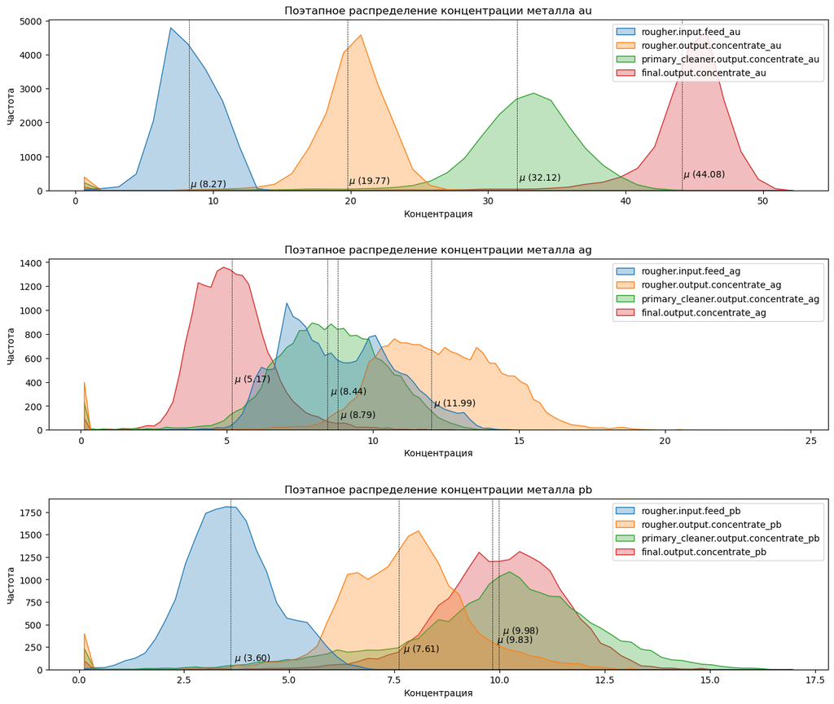

```python
all_means = [] # список средних для сравнения динамики

_, axes = plt.subplots(nrows=3, ncols=1, figsize=(12, 10))
axes = axes.flatten()
for i, metal in enumerate(metals):
    features = [f'{x}_{metal}' for x in feed_features]
    sns.histplot(data_full[features], fill=True, ax=axes[i], element="poly", alpha=0.3)
    axes[i].set_title(f'Поэтапное распределение концентрации металла {metal}')
    axes[i].set_xlabel(f'Концентрация'); axes[i].set_ylabel(f'Частота')

    means = [data_full[f'{x}_{metal}'].mean() for x in feed_features]
    all_means.append(means)
    for m in means:         # вертикальные линии для средних
        axes[i].axvline(m, color='k', linestyle='dashed', linewidth=.5)
        axes[i].text(m+0.1, 100+means.index(m)*100, f'$\mu$ ({m:.2f})')
plt.subplots_adjust(left=0, bottom=0, right=1, top=1, wspace=.15, hspace=.4);
```

```python
means_table = pd.DataFrame(all_means).rename(index={0:'au', 1:'ag', 2:'pb'},
                  columns={0:'флотация', 1:'первичная', 2:'вторичная', 3:'финальная'})
means_table
```

|  | флотация | первичная | вторичная | финальная |
| --- | --- | --- | --- | --- |
| au | 8.266097 | 19.772000 | 32.119400 | 44.076513 |
| ag | 8.794927 | 11.994759 | 8.442408 | 5.168470 |
| pb | 3.598085 | 7.606272 | 9.829530 | 9.978895 |

На графиках, аппроксимирующих плотность распределения, видны описанные выше процессы с соответствующим каждому этапу разбросом значений концентрации.

Также на этих графиках заметны непонятные флуктуации концентрации (около нуля), похожие на выбросы.

### Сравнение распределения размеров гранул сырья на обучающей и тестовой выборках.

```python
grain_features = ['rougher.input.feed_size', 'primary_cleaner.input.feed_size']
_, axes = plt.subplots(nrows=2, ncols=1, figsize=(12, 6))
axes = axes.flatten()

for i, feature in enumerate(grain_features):
    sns.kdeplot(data_train[feature], ax=axes[i], fill=True, alpha=0.1)
    sns.kdeplot(data_test[feature], ax=axes[i], fill=True, alpha=0.1)
    axes[i].set_title(f'Плотность распределение параметра {feature} (размер гранул) на выборках train и test')
    axes[i].set_xlabel(f'Размер гранул ({feature})'); axes[i].set_ylabel(f'Плотность')
    axes[i].legend(['Train', 'Test'])
plt.subplots_adjust(left=0, bottom=0, right=1, top=1, wspace=.15, hspace=.4);
```

[output not shown]

Стандартные статистики распределения этих признаков:

```python
for feature in grain_features:
    grain_stats = pd.concat([data_train[feature].describe(), data_test[feature].describe()], axis=1)
    grain_stats.columns = ['train', 'test']
    print(f'Статистики по признаку {feature}:')
    display(grain_stats)
    print('\n\n')
```

[output not shown]

Видно, что распределения на выборках `data_test` и `data_train` и по виду и по ключевым статистикам очень похожи, что позволяет использовать выборку `data_test` для валидации моделей, полученных при обучении на выборке `data_train`

### Анализ суммарных концентраций на разных стадиях

```python
# построение датафрейма с суммарными показателями концентраций

conc_sum_data = pd.DataFrame(0, index=data_train.index, columns=feed_features)
for feature in feed_features:
    for element in elements:
        conc_sum_data[feature] += data_train[f'{feature}_{element}']
```

```python
plt.figure(figsize=(12, 6))
s_c = sns.histplot(conc_sum_data, fill=True, element="poly", alpha=0.3)

means = conc_sum_data[feed_features].mean().tolist()
for m in means:
    plt.axvline(m, color='k', linestyle='dashed', linewidth=.5)
    plt.text(m+0.1, 300+means.index(m)*50, f'$\mu$ ({m:.2f})')

plt.title('Распределение суммарной концентрации элементов на каждом из этапов')
plt.xlabel('Концентрация'); plt.ylabel('Частота')
plt.subplots_adjust(left=0, bottom=0, right=1, top=1, wspace=.15, hspace=.4);
```

[output not shown]

```python
conc_sum_data[feed_features].describe().loc[['mean', 'std'], :]
```

[output not shown]

Как и на графиках концентраций по отдельным металлам, заметно разнонаправленное движение концентрации в зависимости от этапа:

После флотации и первичной очистки (1-го и 2-го этапов) средняя величина концентрации заметно растет, но также существенно (в $ \approx1,75$ ) раза растет и среднеквадратичное отклонение (СКО), на последующих этапах концентрация сначала резко падает (зато падает и СКО), но на финальном этапе и суммарная концентрация элементов достигает максимальных значений, и СКО существенно снижается.

Также имеет место флуктуация в данных в **около** 0, что может быть выбросом.

Удаляю подозрительные строки из выборки (где эти параметры меньше 1):

```python
for feature in feed_features:
    for element in elements:
        data_train = data_train[data_train[f'{feature}_{element}'] > 1 ]
```

[figure not shown]

```python
plt.figure(figsize=(12, 3))
sns.histplot(data_train['rougher.output.concentrate_pb'], fill=True, color='orange', element="poly", alpha=0.2);
plt.xlabel('Концентрация'); plt.ylabel('Частота')
plt.title('Распределение признака rougher.output.concentrate_pb');
```

## Построение моделей

### Предобработка данных (продолжение)

Добавляю в тестовую выборку отсутствующие признаки:

```python
data_test[target_features] = data_full.loc[data_test.index, target_features]
```

```python
print(f'Размерность признакового пространства выборок:')
print(f'Тестовой: {data_test.shape[1]} \nТренировочной:  {data_train.shape[1]}')
```

```
Размерность признакового пространства выборок:
Тестовой: 54
Тренировочной:  86
```

Избавляюсь от признаков в тренировочной выборке, которых нет в тестовой выборке (**ВАЖНО**: в тестовой выборке не было столбцов целевых признаков, чтобы их не удалить из тренировочной, надо из `nontest_features` убрать `target_features`)

```python
for f in target_features:
    nontest_features.remove(f)

data_train = data_train.drop(nontest_features, axis=1)
```

```python
print(f'Размерность признакового пространства выборок:')
print(f'Тестовой: {data_test.shape[1]} \nТренировочной:  {data_train.shape[1]}')
```

```
Размерность признакового пространства выборок:
Тестовой: 54
Тренировочной:  54
```

Убирание выбросов отсечением 1% наиболее отстоящих значений:

```python
for col in data_train.columns:
    cint_l = np.percentile(data_train[col], 0.5); cint_r = np.percentile(data_train[col], 99.5)
    new_data_train = data_train[(data_train[col] > cint_l) & (data_train[col] < cint_r)]
```

Удаляю нулевые значения целевых признаков:

```python
for i in [0, 1]:
    data_train = data_train[data_train[target_features[i]] != 0]
    data_test = data_test[data_test[target_features[i]] != 0]
```

Разделение признаков и целевой переменной:

```python
features_train = new_data_train.drop(target_features, axis=1)
target_train = new_data_train[target_features]

features_test = data_test.drop(target_features, axis=1)
target_test = data_test[target_features]
```

### Написание функций для вычисления sMAPE

$$ {\mathrm{sMAPE}} = {1 \over N} \sum_{i=1}^{N} {|y_i - \hat{y_i}| \over (|y_i| +|\hat{y_i}|)/2} \cdot 100\% $$

Обозначения:

- $y_i$ - значение целевого признака для объекта с порядковым номером i в выборке, на которой измеряется качество.
- $\hat{y_i}$ - значение предсказания для объекта с порядковым номером i, например, в тестовой выборке.
- $N$ - количество объектов в выборке.
- $\sum_{i=1}^{N}$ - суммирование по всем объектам выборки (i меняется от 1 до N).

$${\mathrm{final\_sMAPE}} = 25\% \cdot {\mathrm{sMAPE(rougher)}} +75\% \cdot {\mathrm{sMAPE(final)}}$$

```python
def smape(target_real, target_pred):
    error = np.divide(np.abs(target_real - target_pred), ((np.abs(target_real) + np.abs(target_pred)) / 2))
    return np.mean(error) * 100



def final_smape(target_real, target_pred):
    return 0.25 * smape(target_real['rougher.output.recovery'], target_pred[:, 0]) + \
           0.75 * smape(target_real['final.output.recovery'], target_pred[:, 1])
```

```python
smape_score = make_scorer(final_smape, greater_is_better=False)
```

### Обучение моделей

Функция для подбора гиперпараметров и обучения методом Cross Validation:

```python
def finetune(model_name, parameters, verbose=10, jobs=-1, **kwargs):
    cv = RandomizedSearchCV(model_name(**kwargs), param_distributions=parameters,
                      scoring=smape_score, cv=3, refit=True, verbose=verbose, n_jobs=jobs)
    cv.fit(features_train, target_train)
    return [cv.best_estimator_, cv.best_params_, -cv.best_score_]
```

#### Тупой регрессор (Baseline)

```python
dummy_r = DummyRegressor(strategy='mean').fit(features_train, target_train)
target_test_pred = dummy_r.predict(features_test)
dummy_r_test_score = final_smape(target_test, target_test_pred)
print(f'(test) Итоговое sMAPE: {dummy_r_test_score:.2f}%')
```

```
(test) Итоговое sMAPE: 7.64%
```

#### Линейная модель

```python
params = {}

lr_best_model, lr_best_params, lr_best_score = finetune(LinearRegression, params)
print(f'лучшие параметры модели: {lr_best_params}')
print(f'(train, CV) лучшее итоговое sMAPE: {lr_best_score:.2f}%')
```

```
Fitting 3 folds for each of 1 candidates, totalling 3 fits
[CV 1/3; 1/1] START ............................................................
[CV 1/3; 1/1] END ........................................... total time=   0.1s
[CV 2/3; 1/1] START ............................................................
```

```
[CV 2/3; 1/1] END ........................................... total time=   0.3s
[CV 3/3; 1/1] START ............................................................
[CV 3/3; 1/1] END ........................................... total time=   0.2s
лучшие параметры модели: {}
(train, CV) лучшее итоговое sMAPE: 10.36%
```

#### Решающее дерево

```python
%%time

params = {'min_samples_split': range(2, 8, 2),
          'min_samples_leaf': range(2, 8, 2),
          'max_depth': range(2, 8, 2)}

dt_best_model, dt_best_params, dt_best_score = finetune(DecisionTreeRegressor, params, random_state=random_state)
print(f'лучшие параметры модели: {dt_best_params}')
print(f'(train, CV) лучшее итоговое sMAPE: {dt_best_score:.2f}%')
print()
```

```
Fitting 3 folds for each of 10 candidates, totalling 30 fits
[CV 1/3; 1/10] START max_depth=2, min_samples_leaf=6, min_samples_split=6.......
[CV 1/3; 1/10] END max_depth=2, min_samples_leaf=6, min_samples_split=6; total time=   0.2s
[CV 2/3; 1/10] START max_depth=2, min_samples_leaf=6, min_samples_split=6.......
[CV 2/3; 1/10] END max_depth=2, min_samples_leaf=6, min_samples_split=6; total time=   0.1s
[CV 3/3; 1/10] START max_depth=2, min_samples_leaf=6, min_samples_split=6.......
[CV 3/3; 1/10] END max_depth=2, min_samples_leaf=6, min_samples_split=6; total time=   0.1s
[CV 1/3; 2/10] START max_depth=4, min_samples_leaf=4, min_samples_split=4.......
[CV 1/3; 2/10] END max_depth=4, min_samples_leaf=4, min_samples_split=4; total time=   0.2s
[CV 2/3; 2/10] START max_depth=4, min_samples_leaf=4, min_samples_split=4.......
[CV 2/3; 2/10] END max_depth=4, min_samples_leaf=4, min_samples_split=4; total time=   0.2s
[CV 3/3; 2/10] START max_depth=4, min_samples_leaf=4, min_samples_split=4.......
[CV 3/3; 2/10] END max_depth=4, min_samples_leaf=4, min_samples_split=4; total time=   0.2s
[CV 1/3; 3/10] START max_depth=4, min_samples_leaf=2, min_samples_split=2.......
[CV 1/3; 3/10] END max_depth=4, min_samples_leaf=2, min_samples_split=2; total time=   0.2s
[CV 2/3; 3/10] START max_depth=4, min_samples_leaf=2, min_samples_split=2.......
[CV 2/3; 3/10] END max_depth=4, min_samples_leaf=2, min_samples_split=2; total time=   0.2s
[CV 3/3; 3/10] START max_depth=4, min_samples_leaf=2, min_samples_split=2.......
[CV 3/3; 3/10] END max_depth=4, min_samples_leaf=2, min_samples_split=2; total time=   0.2s
[CV 1/3; 4/10] START max_depth=6, min_samples_leaf=4, min_samples_split=2.......
[CV 1/3; 4/10] END max_depth=6, min_samples_leaf=4, min_samples_split=2; total time=   0.2s
[CV 2/3; 4/10] START max_depth=6, min_samples_leaf=4, min_samples_split=2.......
[CV 2/3; 4/10] END max_depth=6, min_samples_leaf=4, min_samples_split=2; total time=   0.2s
[CV 3/3; 4/10] START max_depth=6, min_samples_leaf=4, min_samples_split=2.......
[CV 3/3; 4/10] END max_depth=6, min_samples_leaf=4, min_samples_split=2; total time=   0.2s
[CV 1/3; 5/10] START max_depth=2, min_samples_leaf=2, min_samples_split=2.......
[CV 1/3; 5/10] END max_depth=2, min_samples_leaf=2, min_samples_split=2; total time=   0.1s
[CV 2/3; 5/10] START max_depth=2, min_samples_leaf=2, min_samples_split=2.......
[CV 2/3; 5/10] END max_depth=2, min_samples_leaf=2, min_samples_split=2; total time=   0.1s
[CV 3/3; 5/10] START max_depth=2, min_samples_leaf=2, min_samples_split=2.......
[CV 3/3; 5/10] END max_depth=2, min_samples_leaf=2, min_samples_split=2; total time=   0.1s
[CV 1/3; 6/10] START max_depth=4, min_samples_leaf=2, min_samples_split=6.......
[CV 1/3; 6/10] END max_depth=4, min_samples_leaf=2, min_samples_split=6; total time=   0.2s
[CV 2/3; 6/10] START max_depth=4, min_samples_leaf=2, min_samples_split=6.......
[CV 2/3; 6/10] END max_depth=4, min_samples_leaf=2, min_samples_split=6; total time=   0.2s
[CV 3/3; 6/10] START max_depth=4, min_samples_leaf=2, min_samples_split=6.......
[CV 3/3; 6/10] END max_depth=4, min_samples_leaf=2, min_samples_split=6; total time=   0.2s
[CV 1/3; 7/10] START max_depth=4, min_samples_leaf=6, min_samples_split=4.......
[CV 1/3; 7/10] END max_depth=4, min_samples_leaf=6, min_samples_split=4; total time=   0.2s
[CV 2/3; 7/10] START max_depth=4, min_samples_leaf=6, min_samples_split=4.......
```

[output cut: 11 more lines]

```
[CV 2/3; 9/10] START max_depth=4, min_samples_leaf=4, min_samples_split=2.......
[CV 2/3; 9/10] END max_depth=4, min_samples_leaf=4, min_samples_split=2; total time=   0.2s
[CV 3/3; 9/10] START max_depth=4, min_samples_leaf=4, min_samples_split=2.......
[CV 3/3; 9/10] END max_depth=4, min_samples_leaf=4, min_samples_split=2; total time=   0.2s
[CV 1/3; 10/10] START max_depth=6, min_samples_leaf=6, min_samples_split=2......
[CV 1/3; 10/10] END max_depth=6, min_samples_leaf=6, min_samples_split=2; total time=   0.2s
[CV 2/3; 10/10] START max_depth=6, min_samples_leaf=6, min_samples_split=2......
[CV 2/3; 10/10] END max_depth=6, min_samples_leaf=6, min_samples_split=2; total time=   0.2s
[CV 3/3; 10/10] START max_depth=6, min_samples_leaf=6, min_samples_split=2......
[CV 3/3; 10/10] END max_depth=6, min_samples_leaf=6, min_samples_split=2; total time=   0.2s
лучшие параметры модели: {'min_samples_split': 4, 'min_samples_leaf': 6, 'max_depth': 4}
(train, CV) лучшее итоговое sMAPE: 8.71%

CPU times: user 5.13 s, sys: 51.4 ms, total: 5.18 s
Wall time: 5.27 s
```

#### Случайный лес

```python
%%time

params = {
    'n_estimators' : [2, 80],
    'min_samples_leaf': [4, 6],
    'min_samples_split': [4, 6]
}

rf_best_model, rf_best_params, rf_best_score = finetune(RandomForestRegressor, params, random_state=random_state)
print(f'лучшие параметры модели: {rf_best_params}')
print(f'(train, CV) лучшее итоговое sMAPE: {rf_best_score:.2f}%')
print()
```

```
Fitting 3 folds for each of 8 candidates, totalling 24 fits
[CV 1/3; 1/8] START min_samples_leaf=4, min_samples_split=4, n_estimators=2.....
```

```
[CV 1/3; 1/8] END min_samples_leaf=4, min_samples_split=4, n_estimators=2; total time=   0.5s
[CV 2/3; 1/8] START min_samples_leaf=4, min_samples_split=4, n_estimators=2.....
[CV 2/3; 1/8] END min_samples_leaf=4, min_samples_split=4, n_estimators=2; total time=   0.5s
[CV 3/3; 1/8] START min_samples_leaf=4, min_samples_split=4, n_estimators=2.....
[CV 3/3; 1/8] END min_samples_leaf=4, min_samples_split=4, n_estimators=2; total time=   0.5s
[CV 1/3; 2/8] START min_samples_leaf=4, min_samples_split=4, n_estimators=80....
[CV 1/3; 2/8] END min_samples_leaf=4, min_samples_split=4, n_estimators=80; total time=  21.1s
[CV 2/3; 2/8] START min_samples_leaf=4, min_samples_split=4, n_estimators=80....
[CV 2/3; 2/8] END min_samples_leaf=4, min_samples_split=4, n_estimators=80; total time=  19.4s
[CV 3/3; 2/8] START min_samples_leaf=4, min_samples_split=4, n_estimators=80....
[CV 3/3; 2/8] END min_samples_leaf=4, min_samples_split=4, n_estimators=80; total time=  19.2s
[CV 1/3; 3/8] START min_samples_leaf=4, min_samples_split=6, n_estimators=2.....
[CV 1/3; 3/8] END min_samples_leaf=4, min_samples_split=6, n_estimators=2; total time=   0.5s
[CV 2/3; 3/8] START min_samples_leaf=4, min_samples_split=6, n_estimators=2.....
[CV 2/3; 3/8] END min_samples_leaf=4, min_samples_split=6, n_estimators=2; total time=   0.5s
[CV 3/3; 3/8] START min_samples_leaf=4, min_samples_split=6, n_estimators=2.....
[CV 3/3; 3/8] END min_samples_leaf=4, min_samples_split=6, n_estimators=2; total time=   0.5s
[CV 1/3; 4/8] START min_samples_leaf=4, min_samples_split=6, n_estimators=80....
[CV 1/3; 4/8] END min_samples_leaf=4, min_samples_split=6, n_estimators=80; total time=  20.3s
[CV 2/3; 4/8] START min_samples_leaf=4, min_samples_split=6, n_estimators=80....
[CV 2/3; 4/8] END min_samples_leaf=4, min_samples_split=6, n_estimators=80; total time=  18.6s
[CV 3/3; 4/8] START min_samples_leaf=4, min_samples_split=6, n_estimators=80....
[CV 3/3; 4/8] END min_samples_leaf=4, min_samples_split=6, n_estimators=80; total time=  18.9s
[CV 1/3; 5/8] START min_samples_leaf=6, min_samples_split=4, n_estimators=2.....
[CV 1/3; 5/8] END min_samples_leaf=6, min_samples_split=4, n_estimators=2; total time=   0.5s
[CV 2/3; 5/8] START min_samples_leaf=6, min_samples_split=4, n_estimators=2.....
[CV 2/3; 5/8] END min_samples_leaf=6, min_samples_split=4, n_estimators=2; total time=   0.5s
[CV 3/3; 5/8] START min_samples_leaf=6, min_samples_split=4, n_estimators=2.....
[CV 3/3; 5/8] END min_samples_leaf=6, min_samples_split=4, n_estimators=2; total time=   0.4s
[CV 1/3; 6/8] START min_samples_leaf=6, min_samples_split=4, n_estimators=80....
[CV 1/3; 6/8] END min_samples_leaf=6, min_samples_split=4, n_estimators=80; total time=  19.3s
[CV 2/3; 6/8] START min_samples_leaf=6, min_samples_split=4, n_estimators=80....
[CV 2/3; 6/8] END min_samples_leaf=6, min_samples_split=4, n_estimators=80; total time=  17.8s
[CV 3/3; 6/8] START min_samples_leaf=6, min_samples_split=4, n_estimators=80....
[CV 3/3; 6/8] END min_samples_leaf=6, min_samples_split=4, n_estimators=80; total time=  18.3s
[CV 1/3; 7/8] START min_samples_leaf=6, min_samples_split=6, n_estimators=2.....
[CV 1/3; 7/8] END min_samples_leaf=6, min_samples_split=6, n_estimators=2; total time=   0.6s
[CV 2/3; 7/8] START min_samples_leaf=6, min_samples_split=6, n_estimators=2.....
[CV 2/3; 7/8] END min_samples_leaf=6, min_samples_split=6, n_estimators=2; total time=   0.5s
[CV 3/3; 7/8] START min_samples_leaf=6, min_samples_split=6, n_estimators=2.....
[CV 3/3; 7/8] END min_samples_leaf=6, min_samples_split=6, n_estimators=2; total time=   0.5s
[CV 1/3; 8/8] START min_samples_leaf=6, min_samples_split=6, n_estimators=80....
[CV 1/3; 8/8] END min_samples_leaf=6, min_samples_split=6, n_estimators=80; total time=  19.2s
[CV 2/3; 8/8] START min_samples_leaf=6, min_samples_split=6, n_estimators=80....
[CV 2/3; 8/8] END min_samples_leaf=6, min_samples_split=6, n_estimators=80; total time=  18.2s
[CV 3/3; 8/8] START min_samples_leaf=6, min_samples_split=6, n_estimators=80....
[CV 3/3; 8/8] END min_samples_leaf=6, min_samples_split=6, n_estimators=80; total time=  19.3s
лучшие параметры модели: {'n_estimators': 80, 'min_samples_split': 4, 'min_samples_leaf': 6}
(train, CV) лучшее итоговое sMAPE: 8.53%

CPU times: user 4min 26s, sys: 760 ms, total: 4min 27s
Wall time: 4min 28s
```

Лучшей моделью по метрике sMAPE оказалась модель случайного леса. Проверяю её на тестовых данных:

```python
target_pred = rf_best_model.predict(features_test)
rf_test_score = final_smape(target_test, target_pred)
print(f'(test) итоговое sMAPE для модели Random Forest: {rf_test_score:.2f}%')
print(f'(test) итоговое sMAPE для baseline модели (Dummy Regressor): {dummy_r_test_score:.2f}%')
```

```
(test) итоговое sMAPE для модели Random Forest: 7.61%
(test) итоговое sMAPE для baseline модели (Dummy Regressor): 7.64%
```

Итоговая таблица (для вывода):

```python
results_table = pd.DataFrame({'Модель':['Линейная модель', 'Решающее дерево', 'Случайный лес'],
'train sMAPE (%)': [round(i, 2) for i in [lr_best_score, dt_best_score, rf_best_score]]}
).set_index('Модель')
```

## Итоговый вывод

В ходе работы были проанализированы и обработаны предоставленные данные и подготовлена модель машинного обучения, способная на обучающей выборке выдавать прогноз лучше baseline (Dummy Regressor).

Получены следующие результаты:

```python
results_table.sort_values(by='train sMAPE (%)')
```

| Модель | train sMAPE (%) |
| --- | --- |
| Случайный лес | 8.53 |
| Решающее дерево | 8.71 |
| Линейная модель | 10.36 |

На тестовой выборке с помощью лучшей из обученных моделей (Random Forest/Случайный лес) получено значение метрики итогового $sMAPE\approx$ 7,61%, что лучше baseline решения на 0,03% (константная baseline модель - Dummy Regressor - показывает на тестовой выборке результат: $\approx$ 7,64%)

В итоге, удалось обучить модель машинного обучения, которая по метрике sMAPE лучше альтернатив, включая константную baseline модель.